# HW8

Peter Jenkins

4/26/2021

```
##   y1 y2
## 1  0  0
## 2  0  0
## 3  0  1
## 4  0  0
## 5  4  0
## 6  0  0
```

```
##     point time.1 time.2 sky.1 sky.2 wind.1 wind.2    temp.1    temp.2 dist.1
## 1  ks_pc1  10.38   8.92     0     1    0.9    0.0  0.000000  5.000000   37.0
## 2  ks_pc2  10.67   9.13     0     1    1.7    0.0  0.000000  5.000000   44.0
## 3  ks_pc3  10.92   9.35     0     1    0.4    0.0  0.000000  5.000000   38.0
## 4 all_pc1  11.90   9.82     0     0    0.3    0.2 -2.777778 -6.111111   40.0
## 5 all_pc2  12.13  10.08     0     0    0.7    0.2 -2.777778 -6.111111   36.5
## 6 cro_pc1   8.90  11.55     1     0    0.0    0.8  0.000000 11.111111   35.0
##   dist.2 day.1 day.2
## 1     39    38    82
## 2     39    38    82
## 3     39    38    82
## 4     39    40    96
## 5     39    40    96
## 6     37     8    74
```

```
##     point type year     size herb shrub1 bareground woody water shrub5
## 1  ks_pc1 acep    0 6.110759    3      1          1     0     1      1
## 2  ks_pc2 acep    0 6.110759    3      1          1     0     0      1
## 3  ks_pc3 acep    0 6.110759    2      1          2     0     0      1
## 4 all_pc1 acep    0 4.241109    2      1          2     0     0      2
## 5 all_pc2 acep    0 4.241109    1      1          2     0     0      1
## 6 cro_pc1 acep    0 3.217254    3      1          2     0     1      1
```

#Fit an N-mixture model that assumes abundance is a function of wetland size and type, and detection #probability is a function of sky and time (5 points).

```r
fit <- pcount(formula = ~ time + sky ~ size + type,
              data = nmix_data, K = 100)
fit
```

```
##
## Call:
## pcount(formula = ~time + sky ~ size + type, data = nmix_data,
##     K = 100)
##
## Abundance:
##               Estimate     SE     z  P(>|z|)
## (Intercept)    3.26003 1.1714  2.78 5.39e-03
## size          -0.00638 0.0056 -1.14 2.54e-01
## typereference -0.55676 0.1323 -4.21 2.57e-05
##
## Detection:
##             Estimate     SE      z  P(>|z|)
## (Intercept)   -1.762 1.3273 -1.328 1.84e-01
## time          -0.116 0.0267 -4.335 1.46e-05
## sky1          -0.799 0.2042 -3.911 9.18e-05
## sky2          -0.103 0.1486 -0.695 4.87e-01
## sky3          -0.140 0.1809 -0.771 4.40e-01
##
## AIC: 1055.205
```

#2. Write a function that calculates the sum of squared Pearson residuals from a fitted model. This test #statistic can be calculated as:

```r
pear <- function(mod){ # mod is fitted model
  obs <- getY(mod@data) # observed count
   ex <- fitted(mod) #obs prob * expected count
   det <- predict(mod, type = "det")
   detm <- matrix(det$Predicted, byrow = TRUE, ncol = 2) # converting to matrix with 2 columns aka 2 replicates at each site
  ts <- (obs - (ex)) ^ 2 / # chi-square statistic
    ((ex) * (1 - detm))
  return(sum(ts))
}
pear(fit)  # 1025.856 expected value
```

```
## [1] 1025.856
```

3. Use the parboot() function in R to simulate the distribution of this test statistic under the assumption that your fitted model is the data-generating model. Simulate 1000 values of the test statistic. Note that this may take several minutes (5 points).

```r
sims <- parboot(fit, pear, nsim = 1000)
sims
```

```
##
## Call: parboot(object = fit, statistic = pear, nsim = 1000)
##
## Parametric Bootstrap Statistics:
##     t0 mean(t0 - t_B) StdDev(t0 - t_B) Pr(t_B > t0)
## 1 1026            645             36.6            0
##
## t_B quantiles:
##       0% 2.5% 25% 50% 75% 97.5% 100%
## [1,] 293  323 356 376 402   468  544
##
## t0 = Original statistic computed from data
## t_B = Vector of bootstrap samples
```

4. Plot the distribution of the simulated test statistic. Include in this plot the value of your test statistic calculated from your fitted model. What is the null hypothesis you are testing when conducting model checking? Do you reject or fail to reject this null hypothesis? What are the implications for how well you model fits the data (5 points)?

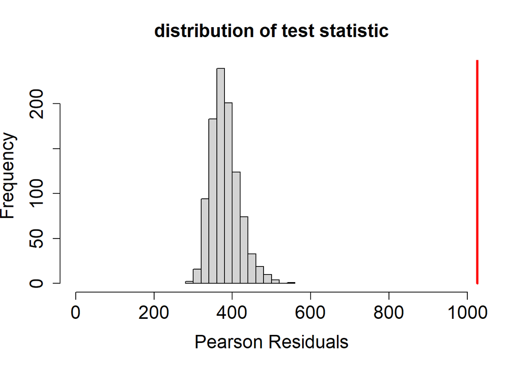

```r
hist(sims@t.star[, 1], xlab = 'Pearson Residuals',
       main = 'distribution of test statistic',
       cex.axis = 1.5, cex.lab = 1.5, cex.main = 1.5, xlim= c(0,1000))
lines(x = rep(pear(fit), 2),
      y = c(0, 1000),
      col = 'red', lwd = 3)
```

```r
sum(sims@t.star[, 1] > pear(fit)) / 1000
```

```
## [1] 0
```

The null hypothesis is that the test statistic could have reasonably arrisen from the theoretical distribution associated with the null hypothesis.

We reject the null hypothesis given the extreme test statistic and the pvalue of 0 Our test statistic does not fall within the distribuition of the generated data,meaning that our model does not fit well with our data.